# World Bank Indicator Visualizations

Evelyn Salas

2/23/2020

## CO2 Emissions by Country

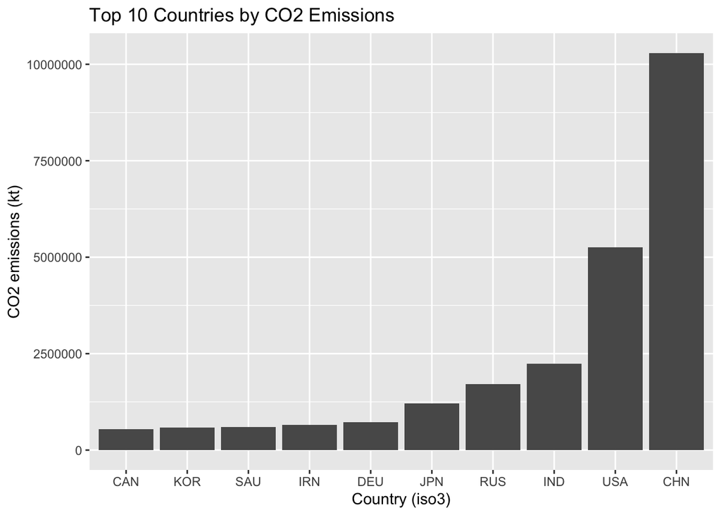

The countries who have manufacturing economies tend to have high carbon emissions.

## US Income Equality over Time

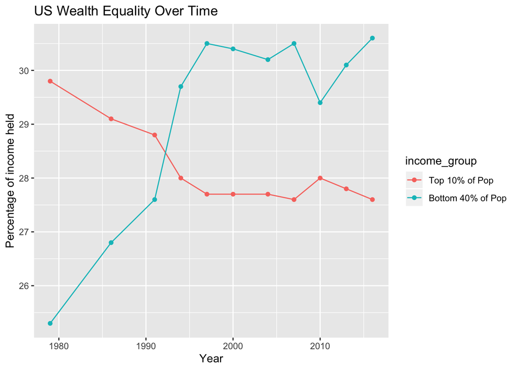

## Health Expenditures by Country

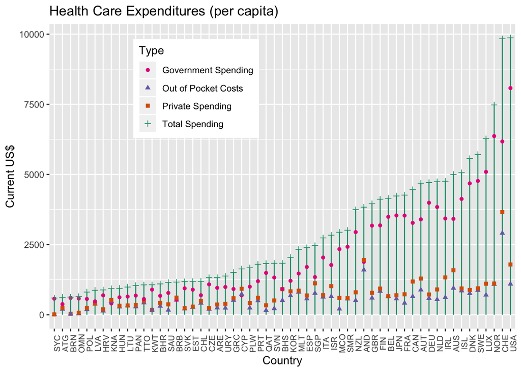

More spending on healthcare does not necessarily mean that people recieve better care. The US spends more on healthcare than almost any other country, but many people are still struggling to get care.

## Changes in Forestation around the World

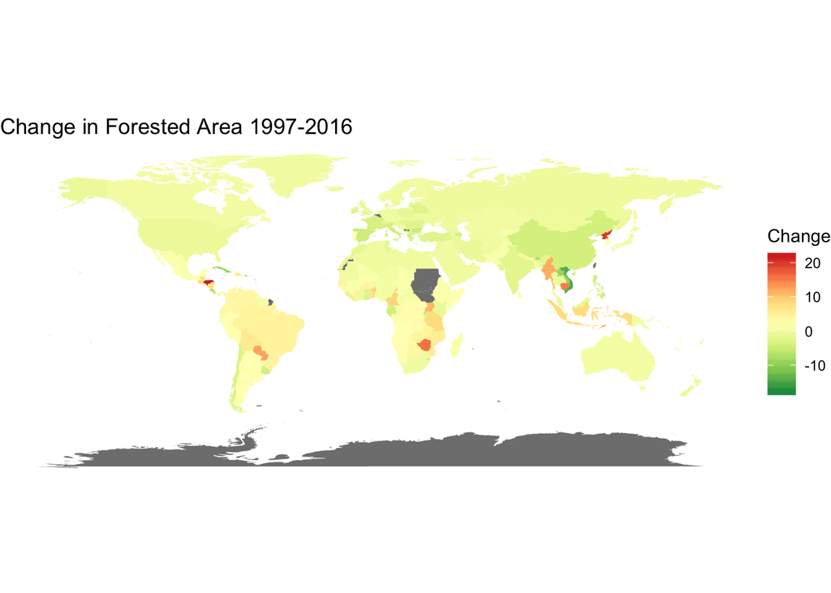

### Teen Pregnancy and Literacy Rates in India Over Time

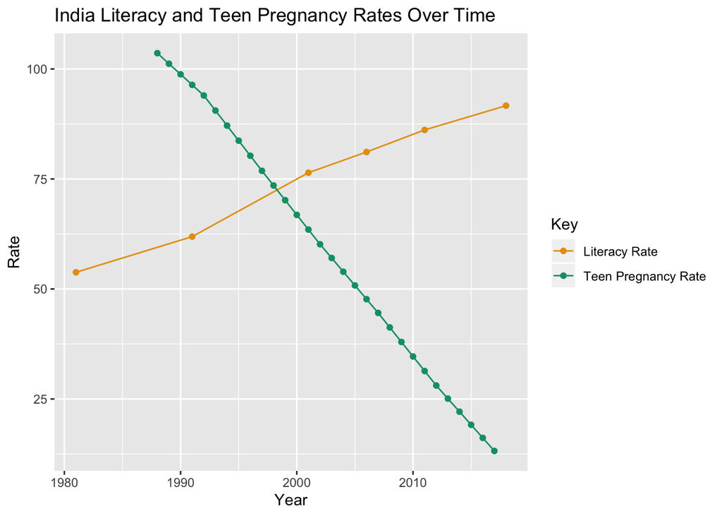

My plot attempts to answer the question: what is the relationship between literacy rate and teen pregnancy in India? The data seems to imply that there is a negative relationship between the two. I choose to look at one specific country over time because I knew that India had seen a very big spike in literacy rates in the past 40 years, so I figured it would interesting to see if this spike coecided with a change in the teen pregnancy rate. I used a line plot because it made it really easy to see the relationship between the two values over a period of time. This visual is effective because it very simple and clear, which makes it easy to read.